# GLM_exercise

Clarke van Steenderen

2025

# Practice exercise 1

The data set **pollinator_abundance_data.csv** contains pollinator abundances on three different flower species, across three seasons (summer, autumn, and winter).

Run the appropriate GLM on this data, and have a look at whether:

1. abundance differs across the three flower hosts
2. abundance differs across seasons
3. season affects abundance differently across the three flower species

Additionally, answer the following:

1. What is the response variable?
2. What is the predictor variable?
3. Do we need to include an interaction term in this model?
4. Which GLM family was appropriate for this data? Provide the relevant model diagnostic plots.
5. Provide box-and-whisker plots to graphically present the data

# Answers

1. The response variable is `pollinator_abundance`. This is the variable we are focusing on.
2. The predictor variables are `flower_sp` and `season`. We want to see how these predictors change our response variable.
3. Yes, as we want to see whether `season` affects `pollinator_abundance` differently on different `flower_sp`. If we do not include an interaction term, our model will assume that `pollinator_abundance` changes with the same magnitude across the different `flower_sp` over different seasons.
4. Since we are dealing with count data, the best approaches are the **poisson** or **negative binomial** GLM families, depending on the degree of overdispersion.

Let’s begin:

```r
if (!require("pacman"))
  install.packages("pacman")
```

```r
pacman::p_load(xlsx, janitor, ggplot2, Rmisc, dplyr,
               tidyverse, visreg, glmmTMB, gtsummary, effects, ggeffects,
               patchwork, emmeans)

# Set plot theme
theme_set(theme_classic() +
theme(panel.border = element_rect(colour = "black", fill = NA),
axis.text = element_text(colour = "black"),
axis.title.x = element_text(margin = unit(c(2, 0, 0, 0), "mm")),
axis.title.y = element_text(margin = unit(c(0, 4, 0, 0), "mm")),
legend.position = "none"))
```

Read in the data, and reorder the season levels:

```r
pollinator.data = read.csv("data/pollinator_abundance_data.csv") %>%
  janitor::clean_names()

# relevel order of seasons
pollinator.data$season = factor(pollinator.data$season,
                                levels = c("Summer", "Autumn", "Winter"))
```

We are working with count data here, and so we will need to fit a Poisson or negative binomial GLM. Let’s start by running an ANOVA (Gaussian GLM), just to see how poorly the model fits the data:

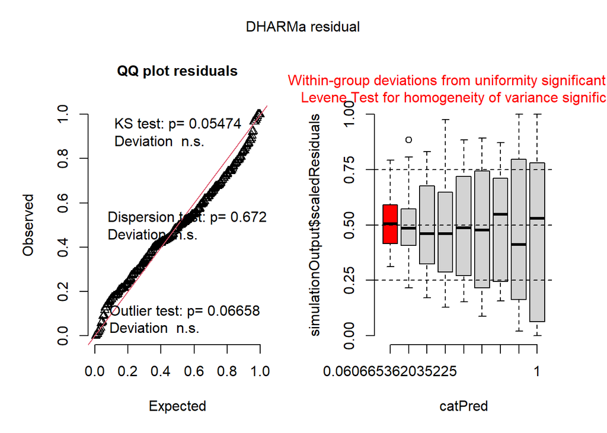

```
## Object of Class DHARMa with simulated residuals based on 250 simulations with refit = FALSE . See ?DHARMa::simulateResiduals for help.
##
## Scaled residual values: 0.572 0.576 0.372 0.288 0.448 0.408 0.42 0.452 0.808 0.62 0.412 0.632 0.572 0.324 0.54 0.396 0.484 0.3 0.62 0.488 ...
```

```r
pollinator.glm.gaus = glm(pollinator_abundance ~ flower_sp +
                            season + flower_sp:season, data = pollinator.data)

DHARMa::simulateResiduals(pollinator.glm.gaus, plot = TRUE)
```

Now we’ll try a Poisson model:

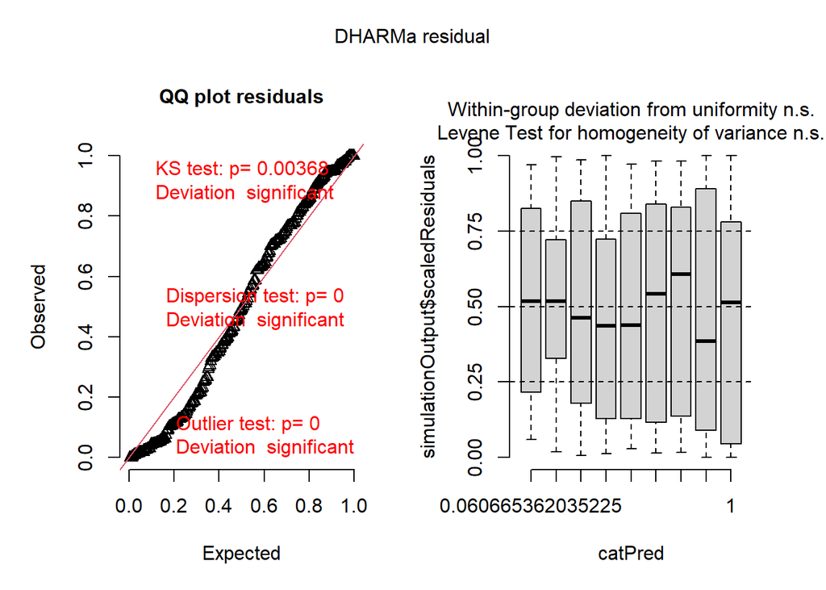

```
## Object of Class DHARMa with simulated residuals based on 250 simulations with refit = FALSE . See ?DHARMa::simulateResiduals for help.
##
## Scaled residual values: 0.5685527 0.542498 0.3472104 0.01840167 0.4861255 0.3286432 0.3649691 0.494934 0.968408 0.7162157 0.1841629 0.7629541 0.721687 0.1319254 0.5529112 0.1863953 0.5575417 0.214195 0.6766313 0.4317987 ...
```

```r
pollinator.glm.pois = glm(pollinator_abundance ~ flower_sp +
                          season + flower_sp:season, family = "poisson",
                          data = pollinator.data)

DHARMa::simulateResiduals(pollinator.glm.pois, plot = TRUE)
```

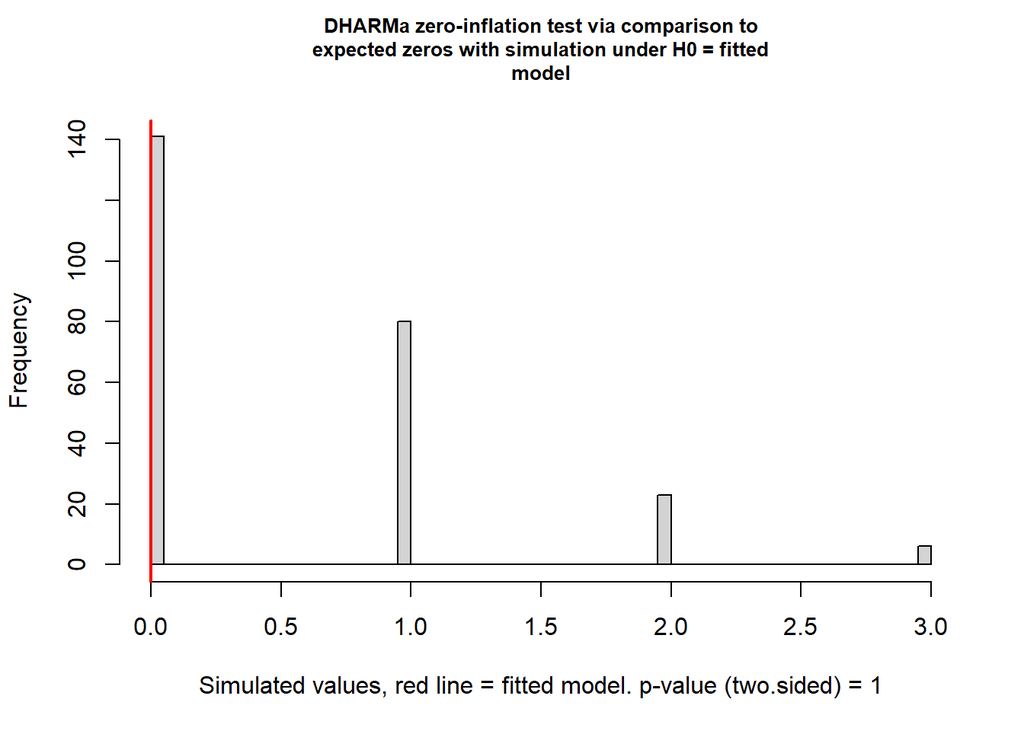

```
##
##  DHARMa zero-inflation test via comparison to expected zeros with
##  simulation under H0 = fitted model
##
## data:  simulationOutput
## ratioObsSim = 0, p-value = 1
## alternative hypothesis: two.sided
```

```r
DHARMa::testZeroInflation(pollinator.glm.pois)
```

The boxplots look better than the Gaussian model, but the QQ plot shows that the points are not falling along the y = x line, that the KS test is significant, that there is significant overdispersion and outliers.

Let’s fit a negative binomial model, to account for overdispersion:

```r
# fit a model with just one predictor: flower species
pollinator.glm.negbin.1 = glmmTMB::glmmTMB(pollinator_abundance ~ flower_sp,
                          family = nbinom2(link = "log"),
                          data = pollinator.data)

# fit another model with both flower species and season
pollinator.glm.negbin.2 = glmmTMB::glmmTMB(pollinator_abundance ~ flower_sp + season,
                          family = nbinom2(link = "log"),
                          data = pollinator.data)

# check which model is better -> the model with both predictors is best
anova(pollinator.glm.negbin.1, pollinator.glm.negbin.2, test = "Chisq")
```

```
## Data: pollinator.data
## Models:
## pollinator.glm.negbin.1: pollinator_abundance ~ flower_sp, zi=~0, disp=~1
## pollinator.glm.negbin.2: pollinator_abundance ~ flower_sp + season, zi=~0, disp=~1
##                         Df    AIC    BIC  logLik deviance  Chisq Chi Df
## pollinator.glm.negbin.1  4 1971.7 1986.0 -981.82   1963.7
## pollinator.glm.negbin.2  6 1806.2 1827.8 -897.09   1794.2 169.47      2
##                         Pr(>Chisq)
## pollinator.glm.negbin.1
## pollinator.glm.negbin.2  < 2.2e-16 ***
## ---
## Signif. codes:  0 '***' 0.001 '**' 0.01 '*' 0.05 '.' 0.1 ' ' 1
```

```r
# fit a model with both predictors, and an interaction term
pollinator.glm.negbin.3 = glmmTMB::glmmTMB(pollinator_abundance ~ flower_sp +
                          season + flower_sp:season,
                          family = nbinom2(link = "log"),
                          data = pollinator.data)

# check whether the interaction term improved the model fit -> yes
anova(pollinator.glm.negbin.2, pollinator.glm.negbin.3, test = "Chisq")
```

```
## Data: pollinator.data
## Models:
## pollinator.glm.negbin.2: pollinator_abundance ~ flower_sp + season, zi=~0, disp=~1
## pollinator.glm.negbin.3: pollinator_abundance ~ flower_sp + season + flower_sp:season, zi=~0, disp=~1
##                         Df    AIC    BIC  logLik deviance  Chisq Chi Df
## pollinator.glm.negbin.2  6 1806.2 1827.8 -897.09   1794.2
## pollinator.glm.negbin.3 10 1642.5 1678.5 -811.23   1622.5 171.72      4
##                         Pr(>Chisq)
## pollinator.glm.negbin.2
## pollinator.glm.negbin.3  < 2.2e-16 ***
## ---
## Signif. codes:  0 '***' 0.001 '**' 0.01 '*' 0.05 '.' 0.1 ' ' 1
```

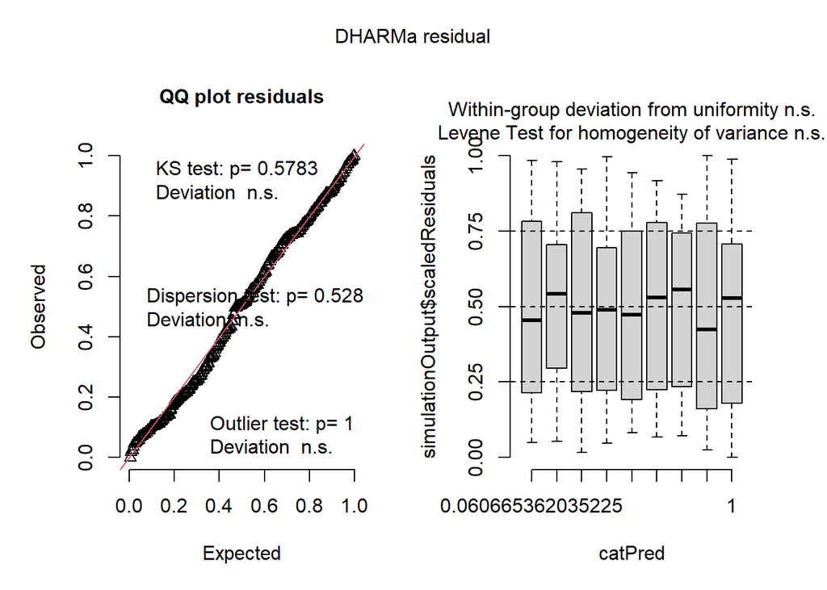

```
## Object of Class DHARMa with simulated residuals based on 250 simulations with refit = FALSE . See ?DHARMa::simulateResiduals for help.
##
## Scaled residual values: 0.6146015 0.5903021 0.3272148 0.05872466 0.5126034 0.3647924 0.2958095 0.4512902 0.9235063 0.7049973 0.2160948 0.8009776 0.7869056 0.1328156 0.6114315 0.205377 0.572801 0.2497256 0.7052076 0.495673 ...
```

```r
# let's get the model diagnostics for model 3
DHARMa::simulateResiduals(pollinator.glm.negbin.3, plot = TRUE)
```

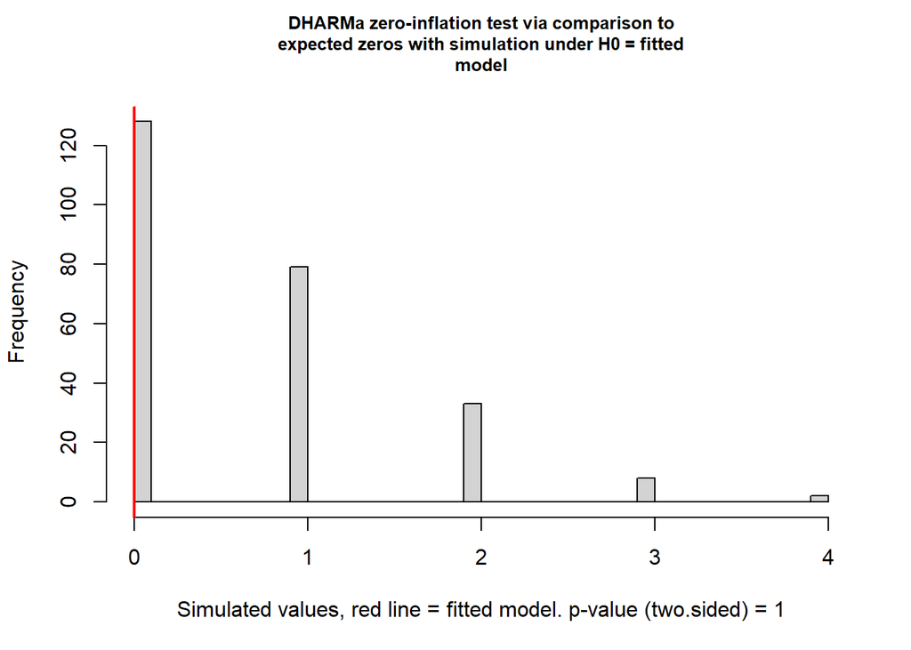

```
##
##  DHARMa zero-inflation test via comparison to expected zeros with
##  simulation under H0 = fitted model
##
## data:  simulationOutput
## ratioObsSim = 0, p-value = 1
## alternative hypothesis: two.sided
```

```r
DHARMa::testZeroInflation(pollinator.glm.negbin.3)
```

```r
car::Anova(pollinator.glm.negbin.3, test = "Chisq", type = "III")
```

```
## Analysis of Deviance Table (Type III Wald chisquare tests)
##
## Response: pollinator_abundance
##                   Chisq Df Pr(>Chisq)
## (Intercept)      831.20  1  < 2.2e-16 ***
## flower_sp        440.97  2  < 2.2e-16 ***
## season           179.53  2  < 2.2e-16 ***
## flower_sp:season 235.54  4  < 2.2e-16 ***
## ---
## Signif. codes:  0 '***' 0.001 '**' 0.01 '*' 0.05 '.' 0.1 ' ' 1
```

```r
# let's get some averages for flower species
Rmisc::summarySE(data = pollinator.data, measurevar = "pollinator_abundance",
                 groupvars = c("flower_sp"))
```

```
##    flower_sp  N pollinator_abundance        sd        se       ci
## 1 flower_sp1 90             10.05556  6.758035 0.7123594 1.415443
## 2 flower_sp2 90             16.54444  9.015793 0.9503480 1.888321
## 3 flower_sp3 90             28.35556 19.653922 2.0717053 4.116434
```

```r
# let's get some averages for season
Rmisc::summarySE(data = pollinator.data, measurevar = "pollinator_abundance",
                 groupvars = c("season"))
```

```
##   season  N pollinator_abundance        sd        se       ci
## 1 Summer 90            28.522222 20.917832 2.2049331 4.381155
## 2 Autumn 90            17.288889  4.878857 0.5142767 1.021857
## 3 Winter 90             9.144444  5.874265 0.6192019 1.230341
```

```r
Rmisc::summarySE(data = pollinator.data, measurevar = "pollinator_abundance",
                 groupvars = c("flower_sp"))
```

```
##    flower_sp  N pollinator_abundance        sd        se       ci
## 1 flower_sp1 90             10.05556  6.758035 0.7123594 1.415443
## 2 flower_sp2 90             16.54444  9.015793 0.9503480 1.888321
## 3 flower_sp3 90             28.35556 19.653922 2.0717053 4.116434
```

```r
# let's get some averages for everything
pollinator.summary = Rmisc::summarySE(data = pollinator.data,
                 measurevar = "pollinator_abundance",
                 groupvars = c("flower_sp", "season"))
```

Let’s make some box plots:

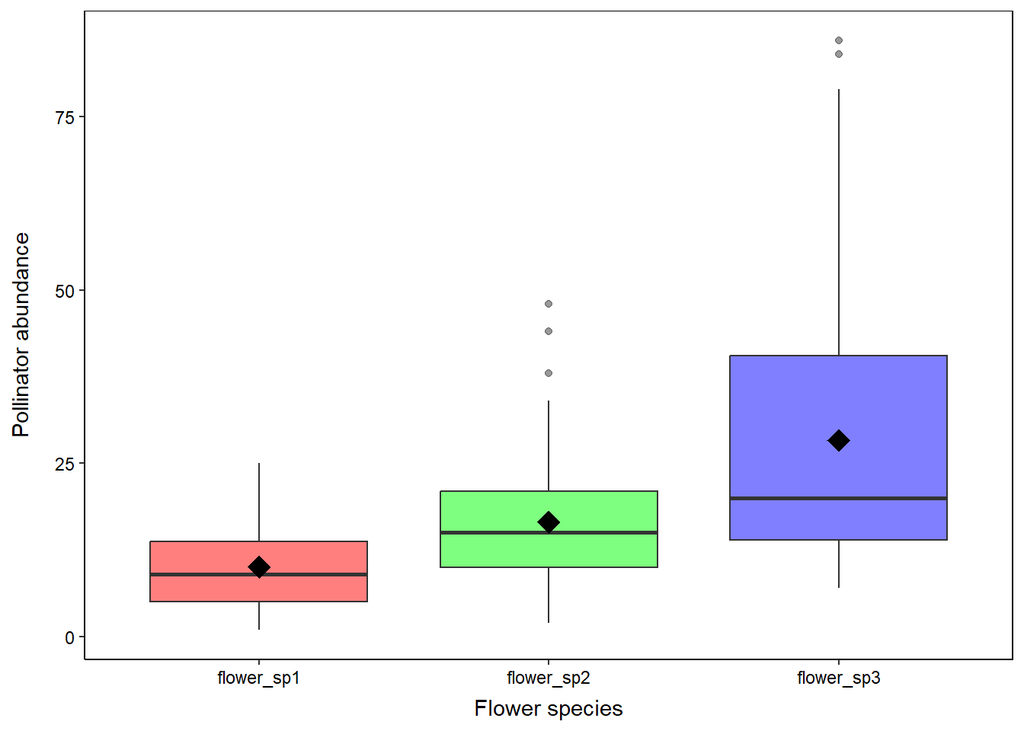

```r
# plot flower species
ggplot2::ggplot(data = pollinator.data,
                aes(x = flower_sp, y = pollinator_abundance)) +
  geom_boxplot(fill = c("red", "green", "blue"), alpha = 0.5) +
  stat_summary(fun = mean, geom = "point", shape = 18, size = 5, fill="black") +
  xlab("Flower species") +
  ylab("Pollinator abundance")
```

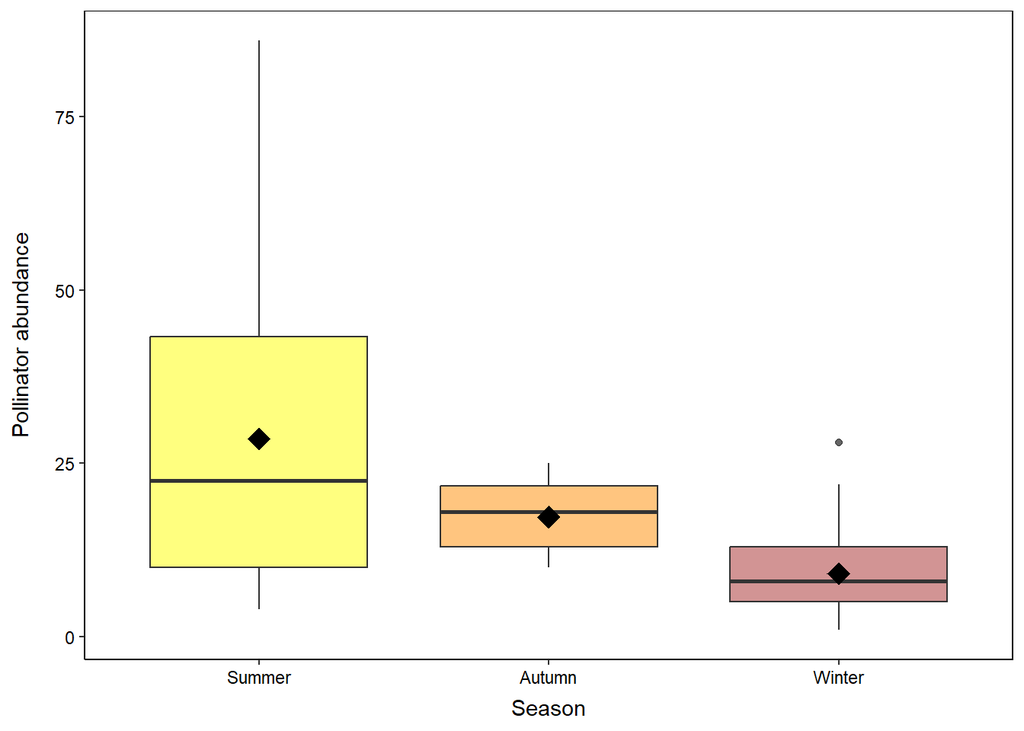

```r
# plot seasons
ggplot2::ggplot(data = pollinator.data,
                aes(x = season, y = pollinator_abundance)) +
  geom_boxplot(fill = c("yellow", "darkorange", "brown"), alpha = 0.5) +
  stat_summary(fun = mean, geom = "point", shape = 18, size = 5, fill="black") +
  xlab("Season") +
  ylab("Pollinator abundance")
```

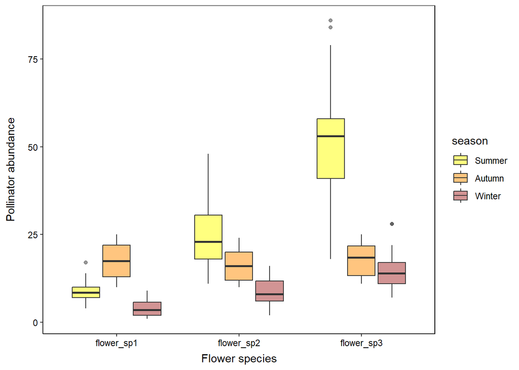

```r
# plot all
ggplot2::ggplot(data = pollinator.data,
                aes(x = flower_sp, y = pollinator_abundance,
                    fill = season)) +
  geom_boxplot(alpha = 0.5) +
  scale_fill_manual(values = c("yellow", "darkorange", "brown")) +
  theme(legend.position = "right") +
  xlab("Flower species") +
  ylab("Pollinator abundance")
```

```r
# run some post hoc tests to see differences between groups
posthoc.season = emmeans::emmeans(pollinator.glm.negbin.3,
                                      pairwise ~ season,
                                      adjust = "tukey")
```

```
## NOTE: Results may be misleading due to involvement in interactions
```

```r
posthoc.flower = emmeans::emmeans(pollinator.glm.negbin.3,
                                      pairwise ~ flower_sp,
                                      adjust = "tukey")
```

```
## NOTE: Results may be misleading due to involvement in interactions
```

```r
posthoc.season$contrasts %>%
  summary(infer = TRUE)
```

```
##  contrast        estimate     SE  df asymp.LCL asymp.UCL z.ratio p.value
##  Summer - Autumn    0.251 0.0486 Inf     0.138     0.365   5.177  <.0001
##  Summer - Winter    1.020 0.0576 Inf     0.885     1.155  17.714  <.0001
##  Autumn - Winter    0.769 0.0575 Inf     0.634     0.904  13.375  <.0001
##
## Results are averaged over the levels of: flower_sp
## Results are given on the log (not the response) scale.
## Confidence level used: 0.95
## Conf-level adjustment: tukey method for comparing a family of 3 estimates
## P value adjustment: tukey method for comparing a family of 3 estimates
```

```r
posthoc.flower$contrasts %>%
  summary(infer = TRUE)
```

```
##  contrast                estimate     SE  df asymp.LCL asymp.UCL z.ratio
##  flower_sp1 - flower_sp2   -0.588 0.0586 Inf    -0.725    -0.451 -10.036
##  flower_sp1 - flower_sp3   -1.045 0.0562 Inf    -1.176    -0.913 -18.581
##  flower_sp2 - flower_sp3   -0.457 0.0489 Inf    -0.571    -0.342  -9.339
##  p.value
##   <.0001
##   <.0001
##   <.0001
##
## Results are averaged over the levels of: season
## Results are given on the log (not the response) scale.
## Confidence level used: 0.95
## Conf-level adjustment: tukey method for comparing a family of 3 estimates
## P value adjustment: tukey method for comparing a family of 3 estimates
```

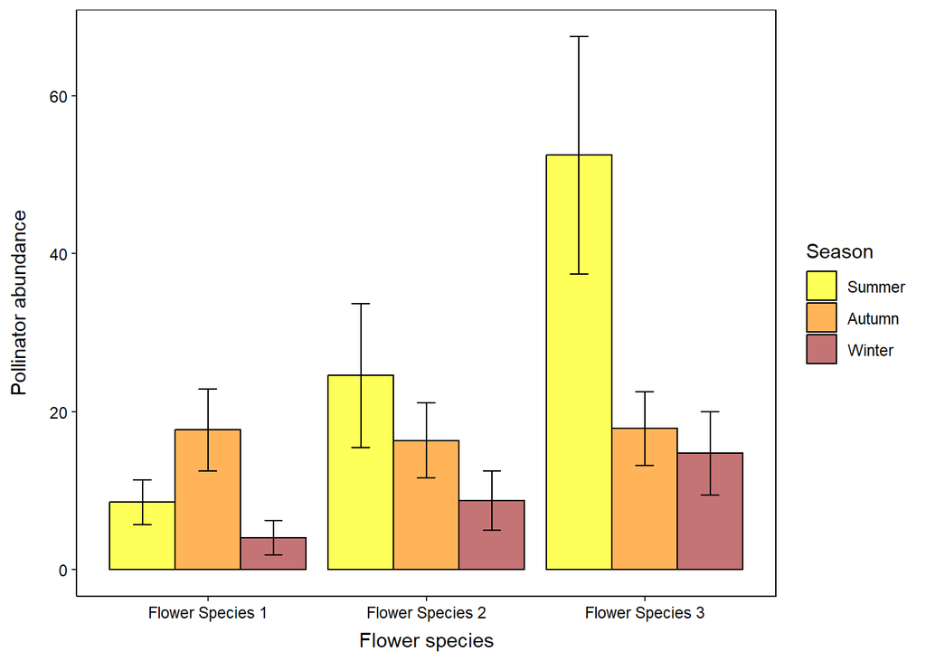

```r
# OVERALL PLOT
ggplot2::ggplot(data = pollinator.summary,
                aes(x = flower_sp, y = pollinator_abundance, fill = season)) +
  geom_bar(stat = "identity", position = position_dodge(),
           alpha = 0.65, colour = "black") +
  geom_errorbar(aes(ymin = pollinator_abundance - sd,
                    ymax = pollinator_abundance + sd),
                position = position_dodge(width = 0.90), width = 0.25) +
  scale_fill_manual(values = c("yellow", "darkorange", "brown")) +
  theme(legend.position = "right") +
  labs(x = "Flower species", y = "Pollinator abundance", fill = "Season") +
  scale_x_discrete(labels = c("flower_sp1" = "Flower Species 1",
                               "flower_sp2" = "Flower Species 2",
                               "flower_sp3" = "Flower Species 3"))
```

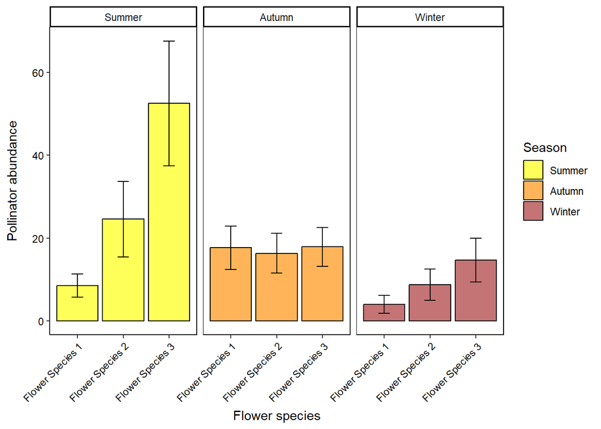

```r
# GROUP BY SEASON
ggplot2::ggplot(data = pollinator.summary,
                aes(x = flower_sp, y = pollinator_abundance, fill = season)) +
  geom_bar(stat = "identity", position = position_dodge(),
           alpha = 0.65, colour = "black") +
  geom_errorbar(aes(ymin = pollinator_abundance - sd,
                    ymax = pollinator_abundance + sd),
                position = position_dodge(width = 0.90), width = 0.25) +
  scale_fill_manual(values = c("yellow", "darkorange", "brown")) +
  theme(legend.position = "right") +
  labs(x = "Flower species", y = "Pollinator abundance", fill = "Season") +
  scale_x_discrete(labels = c("flower_sp1" = "Flower Species 1",
                               "flower_sp2" = "Flower Species 2",
                               "flower_sp3" = "Flower Species 3")) +
  # rotate x axis labels 45 degrees
  theme(axis.text.x = element_text(angle = 45, hjust = 1)) +
  facet_wrap(~season)
```

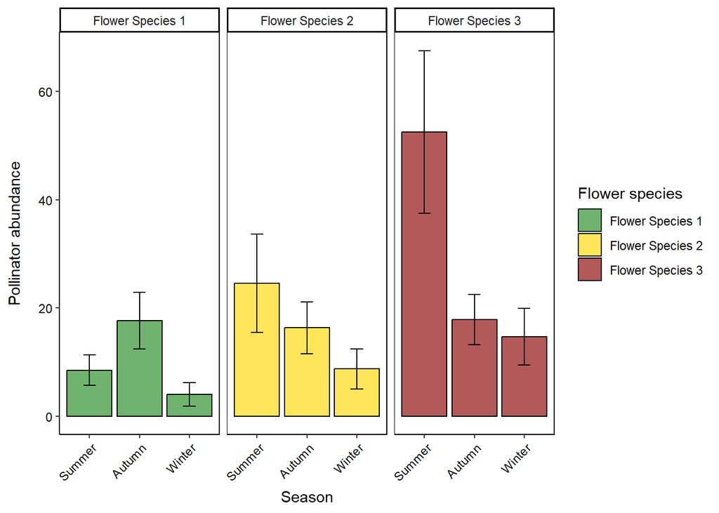

```r
# GROUP BY FLOWER SPECIES
ggplot2::ggplot(data = pollinator.summary,
                aes(x = season, y = pollinator_abundance, fill = flower_sp)) +
  geom_bar(stat = "identity", position = position_dodge(),
           alpha = 0.65, colour = "black") +
  geom_errorbar(aes(ymin = pollinator_abundance - sd,
                    ymax = pollinator_abundance + sd),
                position = position_dodge(width = 0.90), width = 0.25) +
  theme(legend.position = "right") +
  labs(x = "Season", y = "Pollinator abundance", fill = "Flower species") +
  scale_fill_manual(values = c("forestgreen", "gold", "darkred"),
                    labels = c("Flower Species 1", "Flower Species 2",
                               "Flower Species 3")) +
  # rotate x axis labels 45 degrees
  theme(axis.text.x = element_text(angle = 45, hjust = 1)) +
  facet_wrap(~flower_sp,
             labeller = labeller(flower_sp = c("flower_sp1" = "Flower Species 1",
                                               "flower_sp2" = "Flower Species 2",
                                               "flower_sp3" = "Flower Species 3")))
```

```r
# look at our summary
pollinator.summary
```

```
##    flower_sp season  N pollinator_abundance        sd        se       ci
## 1 flower_sp1 Summer 30             8.500000  2.813146 0.5136079 1.050446
## 2 flower_sp1 Autumn 30            17.666667  5.208305 0.9509020 1.944813
## 3 flower_sp1 Winter 30             4.000000  2.181426 0.3982721 0.814558
## 4 flower_sp2 Summer 30            24.566667  9.111127 1.6634567 3.402151
## 5 flower_sp2 Autumn 30            16.333333  4.773008 0.8714281 1.782271
## 6 flower_sp2 Winter 30             8.733333  3.731814 0.6813329 1.393482
## 7 flower_sp3 Summer 30            52.500000 15.041896 2.7462618 5.616736
## 8 flower_sp3 Autumn 30            17.866667  4.658943 0.8506027 1.739678
## 9 flower_sp3 Winter 30            14.700000  5.266354 0.9615003 1.966489
```

If we have a look at a boxplot, combined with our summary table, we can also add that:

- Pollinator abundance was highest on flower sp. 3 (28.4 $\pm$ 19.7), and lowest on flower sp. 1 (10.1 $\pm$ 6.8)
- Pollinator abundance was highest in summer (28.5 $\pm$ 20.9), and lowest in winter (9.1 $\pm$ 5.9), such that winter abundance was 68% lower: (9.1 - 28.5)/(28.5) x 100
- For flower sp. 1, pollinator abundance was highest in autumn, while abundances were highest in summer for flower sp. 2 and sp. 3